# Practical Machine Learning course project

Chris Palmer

20 October 2015

## Introduction

The following is a course project as part of the Coursera Data Science course run by John Hopkins Bloomberg School of Public Health. The purpose of the project is to demonstrate understanding of how to use machine learning for prediction.

The goal of the project is to “use data from accelerometers on the belt, forearm, arm, and dumbbell of 6 participants” to predict the manner in which participants carried out a weight lifting exercise. This follows closely the goal of the original study, which was to use sensors to understand how correctly participants were performing a weight lifting exercise. Data from the study was generously made available to Coursera by the authors: Velloso, E.; Bulling, A.; Gellersen, H.; Ugulino, W.; Fuks, H. Qualitative Activity Recognition of Weight Lifting Exercises. Proceedings of 4th International Conference in Cooperation with SIGCHI (Augmented Human ’13) . Stuttgart, Germany: ACM SIGCHI, 2013. http://groupware.les.inf.puc-rio.br

Data was collected from sensors attached to the arm, belt, glove, and dumbbell while six young health participants were asked to perform one set of 10 repetitions of the Unilateral Dumbbell Biceps Curl in five different ways:

- Class A - Exactly according to specification.
- Class B - Throwing the Elbow to the front.
- Class C - Lifting the Dumbbell only halfway.
- Class D - Lowering the Dumbbell only halfway.
- Class E - Throwing the Hips to the front.

Class A corresponds to the specified correct execution of the exercise, while the other 4 classes correspond to common mistakes. The training data variable identifying each of the 5 exercise classes is named **“classe”** and is the value we need to predict.

The sensors consisted of integrated accelerometers, magnetometers, and gyroscopes. Although the Coursera assignment refers to the sensor as an accelerometer only, this has been interpreted this as a generic label for the integrated sensor, especially in light of the further statement in the assignment to “use any of the other variables to predict with” (i.e. apart from classe which we are trying to predict).

The data was supplied to Coursera students in the form of two CSV files, a set of training data consisting of 19622 records of 160 variables, and a set of 20 records of test data also consisting of 160 variables: The training data has the *classe* variable, while the other variables consist of measurements from the sensors; plus some calculated summary variables such as totals, averages, variants and standard deviations; and fields identifying the participant and the exercise session. The test data had “problem_id” field numbered 1 to 20 instead of classe.

The training data for this project are available here:

https://d396qusza40orc.cloudfront.net/predmachlearn/pml-training.csv

The test data are available here:

https://d396qusza40orc.cloudfront.net/predmachlearn/pml-testing.csv

According to the [study documentation](http://groupware.les.inf.puc-rio.br/public/papers/2013.Velloso.QAR-WLE.pdf), sessions were measured in over a number of seconds, with 2.5 seconds being the optimum “window” of measurements for accurate measurement. During this time many signals are collected and accumulated in a series of records, the last record in a set receives the summary measures briefly described above. For the study the authors used a Random Forest machine learning algorithm, and identified 17 important variables to use: In the belt - the mean and variance of the roll, maximum, range and variance of the accelerometer vector, variance of the gyro and variance of the magnetometer; in the arm - the variance of the accelerometer vector and the maximum and minimum of the magnetometer; in the dumbbell - the maximum of the acceleration, variance of the gyro and maximum and minimum of the magnetometer; and in the glove - the sum of the pitch and the maximum and minimum of the gyro.

It was decided to likewise use a Random Forest algorithm, utilizing the R library randomForest. A comparison study was conducted using train with method=“rf” from the caret package, the results were very similar but the time it took for train to work was 42 minutes, compared to just a few minutes using the randomForest library. The results of using train are elaborated in appendix G.

## Data Analysis

A fairly detailed data analysis was initially begun on the training data. It soon became apparent that there was quite a variability in the range of values obtained over the same exercises when performed by different subjects. It seems likely that these are due to differences in the sensors rather than the participants. There were a number of inconsistencies in the summary data names, with some summary variables seeming to be collecting data from a sensor that did not tally with the name of the summary variable. In addition there were quite a lot of invalid data (NA and Div 0) in the summary fields.

Many of the variables used by the original study are summary variables, or are variables that can only be obtained in the context of a range of measurements in a time window over a single session. However an examination of the test data revealed that none of the summary variables contained valid data (they were all NA), therefore it was concluded that we should remove these variables from both the training and test data, and just proceed with variables that were in common use by both data sets. Furthermore, as the test data consists of individual unrelated records it seemed it would be more useful to concentrate on measurements that can be simply compared to one another, where there is no dependence on measuring averages or variance etc. from within a set of related records.

## Data Preparation

See Appendix A for the details of the data preparation performed in R code.

The supplied training set was aligned with the available columns in the test set by removing columns in both sets that were all NA the test set. Additionally, apart from the identifying subject variable any columns that were not sensor measurements were also removed. The training data was further split to give a test data set so evaluation of the model accuracy could be assessed.

## Deciding on a data model

See Appendix B for the details of the model construction performed in R code.

Create an initial model using Random Forest and specifying importance=TRUE so we can evaluate the most important variables. The randomForest library implicitly performs cross validation as it assembles and examines a large collection of decision trees by first generating a random sample of the original data with replacement (bootstrapping), then selecting and testing variables at random to determine node splitting. Multiple trees are constructed, and the usefulness of each variable in each decision is noted.

```r
print(rf)
```

```
##
## Call:
##  randomForest(formula = classe ~ ., data = training, keep.inbag = TRUE,      importance = TRUE)
##                Type of random forest: classification
##                      Number of trees: 500
## No. of variables tried at each split: 7
##
##         OOB estimate of  error rate: 0.65%
## Confusion matrix:
##      A    B    C    D    E class.error
## A 3344    4    0    0    0 0.001194743
## B   10 2263    6    0    0 0.007020623
## C    0   17 2032    5    0 0.010710808
## D    0    0   25 1903    2 0.013989637
## E    0    0    3    4 2158 0.003233256
```

### Error Analysis

See Appendix C for detailed discussion of error analysis and “out-of-bag” (OOB) error rates.

We have relied on the Random Forest process for cross-validation, as discussed in Appendix C. Random Forest estimates errors as an out-of-bag error rate, and the designers of the process have concluded that OOB has proven to be unbiased in many tests, with very close alignment between estimated and actual error rates.

In Appendix C we examine the error rates and conclude that we could safely reduce our trees from 500 to 192 without losing too much precision. Creating a Random Forest of 192 trees over all the variables reduces the size of it from 48.4 Mb to 20.2 Mb, but increases OOB error by only 0.07%:

```r
print(rf192)
```

```
##
## Call:
##  randomForest(formula = classe ~ ., data = training, keep.inbag = TRUE,      importance = TRUE, ntree = 192)
##                Type of random forest: classification
##                      Number of trees: 192
## No. of variables tried at each split: 7
##
##         OOB estimate of  error rate: 0.72%
## Confusion matrix:
##      A    B    C    D    E  class.error
## A 3346    1    0    0    1 0.0005973716
## B   10 2263    6    0    0 0.0070206231
## C    1   17 2030    6    0 0.0116845180
## D    1    0   31 1895    3 0.0181347150
## E    0    1    3    4 2157 0.0036951501
```

The resulting model is very accurate with an out-of-bag (OOB) estimate of error rate of 0.72%, but using all of the variables may not be necessary, in fact could be over-fitting, so we can retain fewer variables based on their importance…

### Variables Importance

See Appendix D for detail of the Importance analysis performed on various models.

Printing an Importance chart shows around seven variables that are highly significant (the larger numbers in the chart), plus an additional 10 that might be:

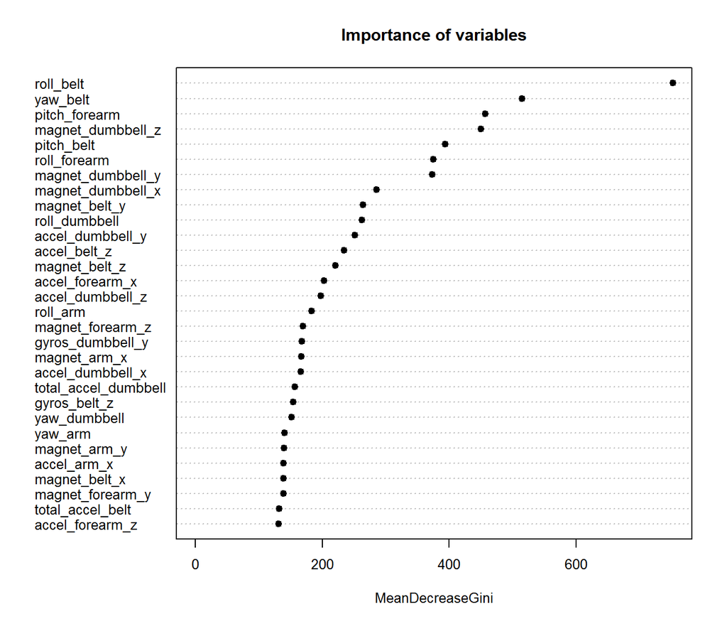

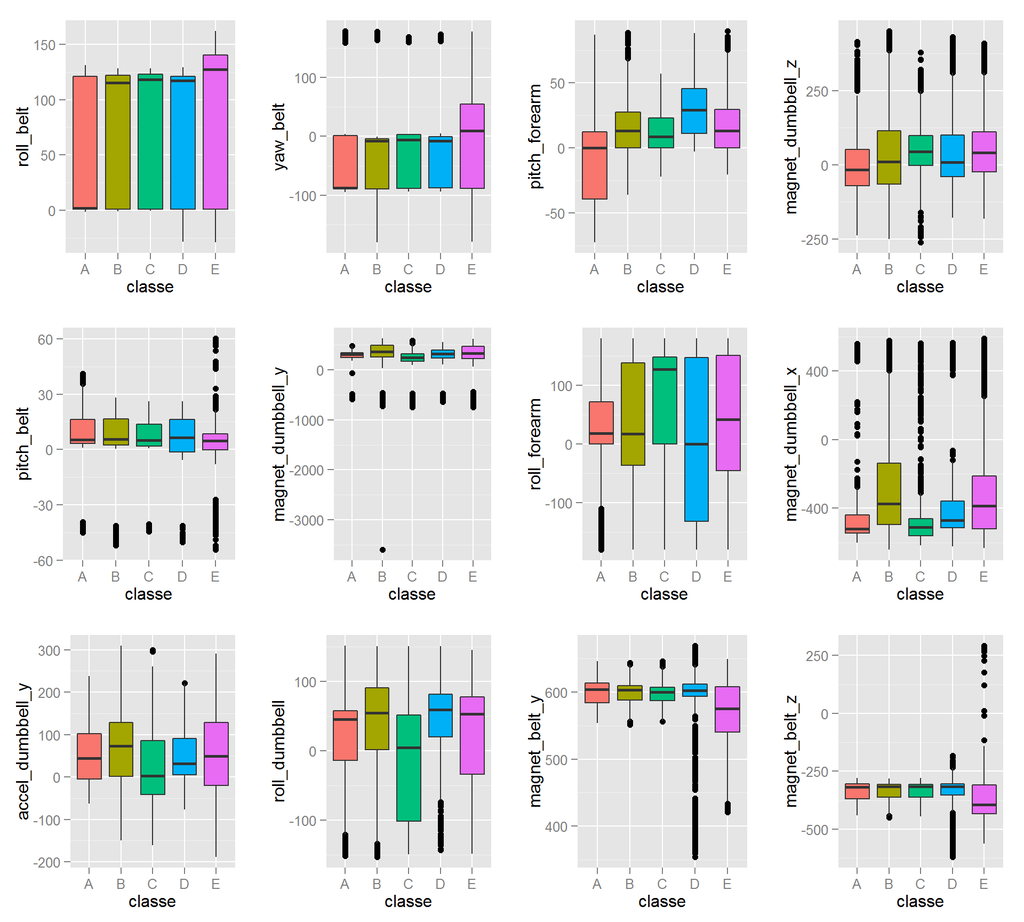

```r
print(rf17final)
```

```
##
## Call:
##  randomForest(formula = classe ~ roll_belt + yaw_belt + pitch_forearm +      magnet_dumbbell_z + pitch_belt + magnet_dumbbell_y + roll_forearm +      magnet_dumbbell_x + accel_dumbbell_y + roll_dumbbell + accel_dumbbell_y +      accel_belt_z + magnet_belt_z + accel_forearm_x + accel_dumbbell_z + …
##                Type of random forest: classification
##                      Number of trees: 500
## No. of variables tried at each split: 3
##
##         OOB estimate of  error rate: 1.21%
## Confusion matrix:
##      A    B    C    D    E class.error
## A 3341    4    1    1    1 0.002090800
## B   18 2227   33    1    0 0.022817025
## C    0   22 2020   12    0 0.016553067
## D    1    1   26 1899    3 0.016062176
## E    0    5    6    8 2146 0.008775982
```

## Testing and using the model prediction

Using the test data we have put aside from our supplied training data, we apply the model, and compare the predicted value delivered by the model against the actual classe variable:

```r
testA$prediction <- predict(rf17final, testA)
cmrfA <- confusionMatrix(testA$prediction, testA$classe)
predictA_accuracy <- round(cmrfA$overall['Accuracy'] * 100, 2)
predictA_accuracy
```

```
## Accuracy
##    98.55
```

```r
# hitRows <- which(testA$prediction == testA$classe)
# missRows <- which(testA$prediction != testA$classe)
# predictA_accuracy <- round((length(hitRows) / (length(hitRows) + length(missRows))) * 100, 2)
# predictA_accuracy
```

```r
testB$prediction <- predict(rf17final, testB)
# hitRows <- which(testB$prediction == testB$classe)
# missRows <- which(testB$prediction != testB$classe)
# predictB_accuracy <- round((length(hitRows) / (length(hitRows) + length(missRows))) * 100, 2)
# predictB_accuracy

cmrfB <- confusionMatrix(testB$prediction, testB$classe)
predictB_accuracy <- round(cmrfB$overall['Accuracy'] * 100, 2)
predictB_accuracy
```

```
## Accuracy
##    98.95
```

The accuracy of our final model when applied to the test data A we created is 98.55%, and against test data B is 98.95%. These are very close to the estimated accuracy of 98.79% (test A is less accurate, test B is more accurate, their average is 98.75%), and we can consider the remainder of subtracting this from 100, which is 1.25%, as our out-of-sample error rate after manual cross validation.

We can now apply the model to the 20 test records in the supplied test data and make predictions to supply to the evaluation process on the Coursera course site.

The predicted classes are not posted here, but upon posting there was a 100% success in prediction.

## Conclusion

The predictions for the supplied test data were confirmed as accurate, so we can say that the Random Forest approach is very suitable to modelling this kind of problem. However it should be noted that analysis revealed that the supplied test data were 20 individual records extracted from the supplied training data, and that a precise match on key values could be made between the test and training data. Theoretically then we could have “predicted” on this data using simple pattern matching, and it’s likely that the strength of the Random Forest approach is to find complex patterns in data like this. Appendix F contains an extract of the logic employed by Random Forest in terms of R code if/else logic, and a dendrogram chart that illustrates the coverage and complexity of the Random Forest approach.

## Appendix A - Data Preparation

Assumes the supplied test and training data CSV files are available in the working directory. Load the test and training data into R; assess the test data for all useful columns; if all of the data in any columns are entirely NA, then eliminate these from both the test and training data. Then remove any columns that are not either measurements or the classe or subject identifier.

```r
suppressPackageStartupMessages({
    library(caret)
    library(randomForest)
    library(ggplot2)
    library(dplyr)
    library(reshape2)
    library(knitr)
    library(grid)
})

set.seed(1000)

# read test data
testdf0 <- read.csv("pml-testing.csv", header=TRUE)
# subset to only include columns that are not all NAs
testdf <- testdf0[, colSums(is.na(testdf0)) != nrow(testdf0)]
# extract the columns names retained
testcols <- colnames(testdf)
# set up same column list for the training data, swapping test data specific
# problem_id column for training data specific classe (what we want to
# train on, and eventually predict)
traincols <- gsub("problem_id", "classe", testcols)

# read training data
traindf0 <- read.csv("pml-training.csv", header=TRUE)
# subset to get only the columns prepared above that we can usefully match on
traindf1 <- traindf0[, traincols]
# for a final training set exclude columns that are not measurements
Colexcl <- c("X", "raw_timestamp_part_1", "raw_timestamp_part_2",
             "cvtd_timestamp", "new_window", "num_window")
# create the training data frame
traindf <- traindf1[,!names(traindf1) %in% Colexcl]

# partition the training data from into training and testing sets, so we
# can evaluate the model before applying to the supplied test data
inTrain = createDataPartition(traindf$classe, p = 0.6)[[1]]
training = traindf[inTrain, ]
testing = traindf[-inTrain, ]
inTest = createDataPartition(testing$classe, p = 0.5)[[1]]
# creating 2 test sets, in case required...
testA = testing[inTest, ]
testB = testing[-inTest, ]
```

## Appendix B - Creation of initial and final models

```r
# 1. Model of all variables
# If we have run this before, load the saved model from the RDS file
if(file.exists("rfmodel.rds")) {
    rf <- readRDS("rfmodel.rds")
} else {
    # Or, run the model and save it to an RDS file
    rf<-randomForest(classe ~ ., data=training, keep.inbag = TRUE, importance=TRUE)
    saveRDS(rf, file = "rfmodel.rds")
}

# OOB error rate of the rf model
rfoob <- ( (sum(rf$confusion[1, 1:5]) - rf$confusion[1, 1]) +
           (sum(rf$confusion[2, 1:5]) - rf$confusion[2, 2]) +
           (sum(rf$confusion[3, 1:5]) - rf$confusion[3, 3]) +
           (sum(rf$confusion[4, 1:5]) - rf$confusion[4, 4]) +
           (sum(rf$confusion[5, 1:5]) - rf$confusion[5, 5]) ) /
    sum(rf$confusion[1:5, 1:5])

rfoob <- round(rfoob * 100, 2)

# 2. Model using 192 trees
if(file.exists("rfmodel192.rds")) {
    rf192 <- readRDS("rfmodel192.rds")
} else {
    # Or, run the model and save it to an RDS file
    rf192 <- randomForest(classe ~ ., data=training, keep.inbag = TRUE, importance=TRUE, ntree=192)
    saveRDS(rf192, file = "rfmodel192.rds")
}

# OOB error rate of the rf192 model
rf192oob <- ( (sum(rf192$confusion[1, 1:5]) - rf192$confusion[1, 1]) +
             (sum(rf192$confusion[2, 1:5]) - rf192$confusion[2, 2]) +
             (sum(rf192$confusion[3, 1:5]) - rf192$confusion[3, 3]) +
             (sum(rf192$confusion[4, 1:5]) - rf192$confusion[4, 4]) +
             (sum(rf192$confusion[5, 1:5]) - rf192$confusion[5, 5]) ) /
    sum(rf192$confusion[1:5, 1:5])

rf192oob <- round(rf192oob * 100, 2)

# 3. Model using top 7 variables
if(file.exists("rf7model.rds")) {
    rf7final <- readRDS("rf7model.rds")
} else {
    rf7final <- randomForest(classe ~ roll_belt + yaw_belt + pitch_forearm +
                            magnet_dumbbell_z  + pitch_belt  + magnet_dumbbell_y +
                            roll_forearm
                          , data=training, importance=TRUE)
    saveRDS(rf7final, file = "rf7model.rds")
}

# 4. Model using top 7 variables and 192 trees
if(file.exists("rf7.192model.rds")) {
    rf7.192final <- readRDS("rf7.192model.rds")
} else {
    rf7.192final <- randomForest(classe ~ roll_belt + yaw_belt + pitch_forearm +
                            magnet_dumbbell_z  + pitch_belt  + magnet_dumbbell_y +
                            roll_forearm
                          , data=training, importance=TRUE, ntree=192)
    saveRDS(rf7.192final, file = "rf7.192model.rds")
}

# 5. Model using top 17 variables
if(file.exists("rf17model.rds")) {
    rf17final <- readRDS("rf17model.rds")
} else {
    rf17final <- randomForest(classe ~ roll_belt + yaw_belt + pitch_forearm + magnet_dumbbell_z +
    pitch_belt  + magnet_dumbbell_y + roll_forearm + magnet_dumbbell_x + accel_dumbbell_y + roll_dumbbell +
    accel_dumbbell_y + accel_belt_z + magnet_belt_z + accel_forearm_x  + accel_dumbbell_z + roll_arm
  , data=training, importance=TRUE)
    saveRDS(rf17final, file = "rf17model.rds")
}

# OOB error rate of the rf17final model
rf17oob <- ( (sum(rf17final$confusion[1, 1:5]) - rf17final$confusion[1, 1]) +
             (sum(rf17final$confusion[2, 1:5]) - rf17final$confusion[2, 2]) +
             (sum(rf17final$confusion[3, 1:5]) - rf17final$confusion[3, 3]) +
             (sum(rf17final$confusion[4, 1:5]) - rf17final$confusion[4, 4]) +
             (sum(rf17final$confusion[5, 1:5]) - rf17final$confusion[5, 5]) ) /
    sum(rf17final$confusion[1:5, 1:5])

rf17oob <- round(rf17oob * 100, 2)

# 6. Model using top 7 variables and 192 trees
if(file.exists("rf17.192model.rds")) {
    rf17.192final <- readRDS("rf17.192model.rds")
} else {
    rf17.192final <- randomForest(classe ~ roll_belt + yaw_belt + pitch_forearm + magnet_dumbbell_z +
    pitch_belt  + magnet_dumbbell_y + roll_forearm + magnet_dumbbell_x + accel_dumbbell_y + roll_dumbbell +
    accel_dumbbell_y + accel_belt_z + magnet_belt_z + accel_forearm_x  + accel_dumbbell_z + roll_arm
  , data=training, importance=TRUE, ntree=192)
   saveRDS(rf17.192final, file = "rf17.192model.rds")
}
```